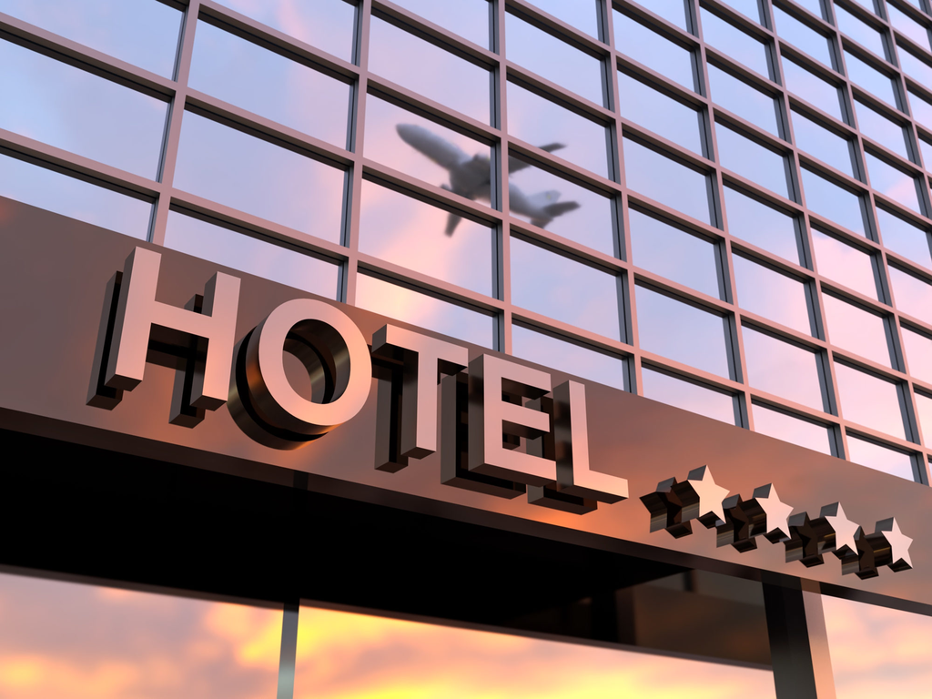

# Natural language processing with Hotel Review Part

First let's look at the data set, which you can download from the here

let's begin by impoting some of the necessary libaries we will be using in this project.

```python
# importing libraries
import numpy as np
import pandas as pd
import matplotlib.pyplot as plt
import seaborn as sns
```

Next, lets read in the data set and take a look at the firest few rows.

```python
hotel_df = pd.read_csv(r"C:\Users\arvin\Downloads\Hotel_Reviews.csv.zip" ,encoding="gb2312")
```

```python
# using head() to print first 5 rows of the dataset.
hotel_df.head()
```

|  | Hotel_Address | Additional_Number_of_Scoring | Review_Date | Average_Score | Hotel_Name | Reviewer_Nationality | Negative_Review | Review_Total_Negative_Word_Counts | Total_Number_of_Reviews | Positive_Review | Review_Total_Positive_Word_Counts | Total_Number_of_Reviews_Reviewer_Has_Given | Reviewer_Score | Tags | days_since_review | lat | lng |
| --- | --- | --- | --- | --- | --- | --- | --- | --- | --- | --- | --- | --- | --- | --- | --- | --- | --- |
| 0 | s Gravesandestraat 55 Oost 1092 AA Amsterdam ... | 194 | 8/3/2017 | 7.7 | Hotel Arena | Russia | I am so angry that i made this post available... | 397 | 1403 | Only the park outside of the hotel was beauti... | 11 | 7 | 2.9 | [' Leisure trip ', ' Couple ', ' Duplex Double... | 0 days | 52.360576 | 4.915968 |
| 1 | s Gravesandestraat 55 Oost 1092 AA Amsterdam ... | 194 | 8/3/2017 | 7.7 | Hotel Arena | Ireland | No Negative | 0 | 1403 | No real complaints the hotel was great great ... | 105 | 7 | 7.5 | [' Leisure trip ', ' Couple ', ' Duplex Double... | 0 days | 52.360576 | 4.915968 |
| 2 | s Gravesandestraat 55 Oost 1092 AA Amsterdam ... | 194 | 7/31/2017 | 7.7 | Hotel Arena | Australia | Rooms are nice but for elderly a bit difficul... | 42 | 1403 | Location was good and staff were ok It is cut... | 21 | 9 | 7.1 | [' Leisure trip ', ' Family with young childre... | 3 days | 52.360576 | 4.915968 |
| 3 | s Gravesandestraat 55 Oost 1092 AA Amsterdam ... | 194 | 7/31/2017 | 7.7 | Hotel Arena | United Kingdom | My room was dirty and I was afraid to walk ba... | 210 | 1403 | Great location in nice surroundings the bar a... | 26 | 1 | 3.8 | [' Leisure trip ', ' Solo traveler ', ' Duplex... | 3 days | 52.360576 | 4.915968 |
| 4 | s Gravesandestraat 55 Oost 1092 AA Amsterdam ... | 194 | 7/24/2017 | 7.7 | Hotel Arena | New Zealand | You When I booked with your company on line y... | 140 | 1403 | Amazing location and building Romantic setting | 8 | 3 | 6.7 | [' Leisure trip ', ' Couple ', ' Suite ', ' St... | 10 days | 52.360576 | 4.915968 |

```python
# using info() to print information about the dataset.
hotel_df.info()
```

```
<class 'pandas.core.frame.DataFrame'>
RangeIndex: 515738 entries, 0 to 515737
Data columns (total 17 columns):
 #   Column                                      Non-Null Count   Dtype
---  ------                                      --------------   -----
 0   Hotel_Address                               515738 non-null  object
 1   Additional_Number_of_Scoring                515738 non-null  int64
 2   Review_Date                                 515738 non-null  object
 3   Average_Score                               515738 non-null  float64
 4   Hotel_Name                                  515738 non-null  object
 5   Reviewer_Nationality                        515738 non-null  object
 6   Negative_Review                             515738 non-null  object
 7   Review_Total_Negative_Word_Counts           515738 non-null  int64
 8   Total_Number_of_Reviews                     515738 non-null  int64
 9   Positive_Review                             515738 non-null  object
 10  Review_Total_Positive_Word_Counts           515738 non-null  int64
 11  Total_Number_of_Reviews_Reviewer_Has_Given  515738 non-null  int64
 12  Reviewer_Score                              515738 non-null  float64
 13  Tags                                        515738 non-null  object
 14  days_since_review                           515738 non-null  object
 15  lat                                         512470 non-null  float64
 16  lng                                         512470 non-null  float64
dtypes: float64(4), int64(5), object(8)
memory usage: 66.9+ MB
```

```python
# using the is null.sum about dataset
hotel_df.isnull
```

[output not shown]

[output cut: 116 more lines]

```python
hotel_df.isnull().sum()
```

```
Hotel_Address                                    0
Additional_Number_of_Scoring                     0
Review_Date                                      0
Average_Score                                    0
Hotel_Name                                       0
Reviewer_Nationality                             0
Negative_Review                                  0
Review_Total_Negative_Word_Counts                0
Total_Number_of_Reviews                          0
Positive_Review                                  0
Review_Total_Positive_Word_Counts                0
Total_Number_of_Reviews_Reviewer_Has_Given       0
Reviewer_Score                                   0
Tags                                             0
days_since_review                                0
lat                                           3268
lng                                           3268
dtype: int64
```

As we can see, there are over 3000 missing values in the lat and lng columns. Let's take a look at the rows with missing values and see if we can find a pattern.

```python
# taking a look at the null values
nulls = hotel_df[hotel_df.isnull().any(axis=1)]
```

```python
nulls.head()
```

|  | Hotel_Address | Additional_Number_of_Scoring | Review_Date | Average_Score | Hotel_Name | Reviewer_Nationality | Negative_Review | Review_Total_Negative_Word_Counts | Total_Number_of_Reviews | Positive_Review | Review_Total_Positive_Word_Counts | Total_Number_of_Reviews_Reviewer_Has_Given | Reviewer_Score | Tags | days_since_review | lat | lng |
| --- | --- | --- | --- | --- | --- | --- | --- | --- | --- | --- | --- | --- | --- | --- | --- | --- | --- |
| 99488 | 20 Rue De La Ga t 14th arr 75014 Paris France | 22 | 8/3/2017 | 7.8 | Mercure Paris Gare Montparnasse | Australia | No Negative | 0 | 377 | Upgraded rooms are excellent Good size for tr... | 25 | 6 | 10.0 | [' Leisure trip ', ' Couple ', ' Standard Room... | 0 days | NaN | NaN |
| 99489 | 20 Rue De La Ga t 14th arr 75014 Paris France | 22 | 8/3/2017 | 7.8 | Mercure Paris Gare Montparnasse | United Kingdom | Noise Not being told about this when we check... | 12 | 377 | The location was great However renovations we... | 45 | 1 | 6.7 | [' Leisure trip ', ' Couple ', ' Standard Room... | 0 days | NaN | NaN |
| 99490 | 20 Rue De La Ga t 14th arr 75014 Paris France | 22 | 7/25/2017 | 7.8 | Mercure Paris Gare Montparnasse | United States of America | Room was worn down One of the curtains did no... | 43 | 377 | Location was good | 5 | 1 | 5.4 | [' Leisure trip ', ' Solo traveler ', ' Standa... | 9 days | NaN | NaN |
| 99491 | 20 Rue De La Ga t 14th arr 75014 Paris France | 22 | 6/22/2017 | 7.8 | Mercure Paris Gare Montparnasse | Australia | Access to shower was by the tub which is very... | 54 | 377 | No Positive | 0 | 13 | 8.3 | [' Leisure trip ', ' Couple ', ' Standard Twin... | 42 days | NaN | NaN |
| 99492 | 20 Rue De La Ga t 14th arr 75014 Paris France | 22 | 5/24/2017 | 7.8 | Mercure Paris Gare Montparnasse | United States of America | The breakfast was way over priced and the sta... | 83 | 377 | The property was conveniently located near th... | 11 | 2 | 5.8 | [' Leisure trip ', ' Couple ', ' Standard Room... | 71 days | NaN | NaN |

```python
# checking the count of unique values in the missing rows
count_n = nulls['Hotel_Address'].nunique()

print(f'There are {count_n} unique hotel addresses with missing values')
```

```
There are 17 unique hotel addresses with missing values
```

```python
# importing cleaned dataset
hotel_df_cleaned = pd.read_csv(r"C:\Users\arvin\Downloads\Hotel_Reviews.csv.zip" ,encoding="latin-1")
```

```python
hotel_df_cleaned.head(6)
```

|  | Hotel_Address | Additional_Number_of_Scoring | Review_Date | Average_Score | Hotel_Name | Reviewer_Nationality | Negative_Review | Review_Total_Negative_Word_Counts | Total_Number_of_Reviews | Positive_Review | Review_Total_Positive_Word_Counts | Total_Number_of_Reviews_Reviewer_Has_Given | Reviewer_Score | Tags | days_since_review | lat | lng |
| --- | --- | --- | --- | --- | --- | --- | --- | --- | --- | --- | --- | --- | --- | --- | --- | --- | --- |
| 0 | s Gravesandestraat 55 Oost 1092 AA Amsterdam ... | 194 | 8/3/2017 | 7.7 | Hotel Arena | Russia | I am so angry that i made this post available... | 397 | 1403 | Only the park outside of the hotel was beauti... | 11 | 7 | 2.9 | [' Leisure trip ', ' Couple ', ' Duplex Double... | 0 days | 52.360576 | 4.915968 |
| 1 | s Gravesandestraat 55 Oost 1092 AA Amsterdam ... | 194 | 8/3/2017 | 7.7 | Hotel Arena | Ireland | No Negative | 0 | 1403 | No real complaints the hotel was great great ... | 105 | 7 | 7.5 | [' Leisure trip ', ' Couple ', ' Duplex Double... | 0 days | 52.360576 | 4.915968 |
| 2 | s Gravesandestraat 55 Oost 1092 AA Amsterdam ... | 194 | 7/31/2017 | 7.7 | Hotel Arena | Australia | Rooms are nice but for elderly a bit difficul... | 42 | 1403 | Location was good and staff were ok It is cut... | 21 | 9 | 7.1 | [' Leisure trip ', ' Family with young childre... | 3 days | 52.360576 | 4.915968 |
| 3 | s Gravesandestraat 55 Oost 1092 AA Amsterdam ... | 194 | 7/31/2017 | 7.7 | Hotel Arena | United Kingdom | My room was dirty and I was afraid to walk ba... | 210 | 1403 | Great location in nice surroundings the bar a... | 26 | 1 | 3.8 | [' Leisure trip ', ' Solo traveler ', ' Duplex... | 3 days | 52.360576 | 4.915968 |
| 4 | s Gravesandestraat 55 Oost 1092 AA Amsterdam ... | 194 | 7/24/2017 | 7.7 | Hotel Arena | New Zealand | You When I booked with your company on line y... | 140 | 1403 | Amazing location and building Romantic setting | 8 | 3 | 6.7 | [' Leisure trip ', ' Couple ', ' Suite ', ' St... | 10 days | 52.360576 | 4.915968 |
| 5 | s Gravesandestraat 55 Oost 1092 AA Amsterdam ... | 194 | 7/24/2017 | 7.7 | Hotel Arena | Poland | Backyard of the hotel is total mess shouldn t... | 17 | 1403 | Good restaurant with modern design great chil... | 20 | 1 | 6.7 | [' Leisure trip ', ' Group ', ' Duplex Double ... | 10 days | 52.360576 | 4.915968 |

let's check to see if there are any more missing values.

```python
# checking for missing vales
hotel_df_cleaned.isnull().sum()
```

```
Hotel_Address                                    0
Additional_Number_of_Scoring                     0
Review_Date                                      0
Average_Score                                    0
Hotel_Name                                       0
Reviewer_Nationality                             0
Negative_Review                                  0
Review_Total_Negative_Word_Counts                0
Total_Number_of_Reviews                          0
Positive_Review                                  0
Review_Total_Positive_Word_Counts                0
Total_Number_of_Reviews_Reviewer_Has_Given       0
Reviewer_Score                                   0
Tags                                             0
days_since_review                                0
lat                                           3268
lng                                           3268
dtype: int64
```

```python
hotel_df_cleaned.shape
```

```
(515738, 17)
```

```python
hotel_df_cleaned.describe()
```

|  | Additional_Number_of_Scoring | Average_Score | Review_Total_Negative_Word_Counts | Total_Number_of_Reviews | Review_Total_Positive_Word_Counts | Total_Number_of_Reviews_Reviewer_Has_Given | Reviewer_Score | lat | lng |
| --- | --- | --- | --- | --- | --- | --- | --- | --- | --- |
| count | 515738.000000 | 515738.000000 | 515738.000000 | 515738.000000 | 515738.000000 | 515738.000000 | 515738.000000 | 512470.000000 | 512470.000000 |
| mean | 498.081836 | 8.397487 | 18.539450 | 2743.743944 | 17.776458 | 7.166001 | 8.395077 | 49.442439 | 2.823803 |
| std | 500.538467 | 0.548048 | 29.690831 | 2317.464868 | 21.804185 | 11.040228 | 1.637856 | 3.466325 | 4.579425 |
| min | 1.000000 | 5.200000 | 0.000000 | 43.000000 | 0.000000 | 1.000000 | 2.500000 | 41.328376 | -0.369758 |
| 25% | 169.000000 | 8.100000 | 2.000000 | 1161.000000 | 5.000000 | 1.000000 | 7.500000 | 48.214662 | -0.143372 |
| 50% | 341.000000 | 8.400000 | 9.000000 | 2134.000000 | 11.000000 | 3.000000 | 8.800000 | 51.499981 | 0.010607 |
| 75% | 660.000000 | 8.800000 | 23.000000 | 3613.000000 | 22.000000 | 8.000000 | 9.600000 | 51.516288 | 4.834443 |
| max | 2682.000000 | 9.800000 | 408.000000 | 16670.000000 | 395.000000 | 355.000000 | 10.000000 | 52.400181 | 16.429233 |

```python
hotel_df_cleaned.info()
```

```
<class 'pandas.core.frame.DataFrame'>
RangeIndex: 515738 entries, 0 to 515737
Data columns (total 17 columns):
 #   Column                                      Non-Null Count   Dtype
---  ------                                      --------------   -----
 0   Hotel_Address                               515738 non-null  object
 1   Additional_Number_of_Scoring                515738 non-null  int64
 2   Review_Date                                 515738 non-null  object
 3   Average_Score                               515738 non-null  float64
 4   Hotel_Name                                  515738 non-null  object
 5   Reviewer_Nationality                        515738 non-null  object
 6   Negative_Review                             515738 non-null  object
 7   Review_Total_Negative_Word_Counts           515738 non-null  int64
 8   Total_Number_of_Reviews                     515738 non-null  int64
 9   Positive_Review                             515738 non-null  object
 10  Review_Total_Positive_Word_Counts           515738 non-null  int64
 11  Total_Number_of_Reviews_Reviewer_Has_Given  515738 non-null  int64
 12  Reviewer_Score                              515738 non-null  float64
 13  Tags                                        515738 non-null  object
 14  days_since_review                           515738 non-null  object
 15  lat                                         512470 non-null  float64
 16  lng                                         512470 non-null  float64
dtypes: float64(4), int64(5), object(8)
memory usage: 66.9+ MB
```

```python
# looking into the duplicated rows
hotel_df_cleaned[hotel_df_cleaned.duplicated().sort_values(ascending=False)].head(6)
```

|  | Hotel_Address | Additional_Number_of_Scoring | Review_Date | Average_Score | Hotel_Name | Reviewer_Nationality | Negative_Review | Review_Total_Negative_Word_Counts | Total_Number_of_Reviews | Positive_Review | Review_Total_Positive_Word_Counts | Total_Number_of_Reviews_Reviewer_Has_Given | Reviewer_Score | Tags | days_since_review | lat | lng |
| --- | --- | --- | --- | --- | --- | --- | --- | --- | --- | --- | --- | --- | --- | --- | --- | --- | --- |
| 23704 | 100 110 Euston Road Camden London NW1 2AJ Unit... | 728 | 2/25/2017 | 8.9 | Pullman London St Pancras | China | none | 2 | 3168 | good location and super nice staff room is bi... | 13 | 39 | 9.6 | [' Business trip ', ' Solo traveler ', ' Class... | 159 day | 51.528677 | -0.128349 |
| 61876 | 16 22 Great Russell Street Camden London WC1B ... | 300 | 7/27/2017 | 9.0 | The Bloomsbury Hotel | Israel | No Negative | 0 | 1254 | The attention received by Sebastian and his t... | 12 | 4 | 9.6 | [' Leisure trip ', ' Couple ', ' Superior Doub... | 7 days | 51.517167 | -0.129053 |
| 68967 | 167 rue de Rome 17th arr 75017 Paris France | 11 | 6/23/2017 | 6.8 | Villa Eugenie | Netherlands | Location is very old not invested in past yea... | 41 | 165 | Location is central accessible by train parki... | 12 | 24 | 4.6 | [' Business trip ', ' Solo traveler ', ' Singl... | 41 days | 48.887128 | 2.314205 |
| 68968 | 167 rue de Rome 17th arr 75017 Paris France | 11 | 4/27/2017 | 6.8 | Villa Eugenie | United Kingdom | This hotel I don t think so is 4 star B B hav... | 93 | 165 | Nothing | 2 | 10 | 2.5 | [' Business trip ', ' Solo traveler ', ' Singl... | 98 days | 48.887128 | 2.314205 |
| 68969 | 167 rue de Rome 17th arr 75017 Paris France | 11 | 3/4/2017 | 6.8 | Villa Eugenie | South Africa | The staff were not helpful at all It took us ... | 69 | 165 | Near bus terminal | 4 | 4 | 5.0 | [' Leisure trip ', ' Couple ', ' Twin Room ', ... | 152 day | 48.887128 | 2.314205 |
| 68970 | 167 rue de Rome 17th arr 75017 Paris France | 11 | 10/20/2016 | 6.8 | Villa Eugenie | Lithuania | We booked hotel for 3 nights and there was no... | 39 | 165 | Good place | 4 | 9 | 6.7 | [' Business trip ', ' Group ', ' Superior Doub... | 287 day | 48.887128 | 2.314205 |

```python
# looking into the duplicated rows
hotel_df_cleaned[hotel_df_cleaned.duplicated().sort_values(ascending=True)].head(10)
```

|  | Hotel_Address | Additional_Number_of_Scoring | Review_Date | Average_Score | Hotel_Name | Reviewer_Nationality | Negative_Review | Review_Total_Negative_Word_Counts | Total_Number_of_Reviews | Positive_Review | Review_Total_Positive_Word_Counts | Total_Number_of_Reviews_Reviewer_Has_Given | Reviewer_Score | Tags | days_since_review | lat | lng |
| --- | --- | --- | --- | --- | --- | --- | --- | --- | --- | --- | --- | --- | --- | --- | --- | --- | --- |
| 23704 | 100 110 Euston Road Camden London NW1 2AJ Unit... | 728 | 2/25/2017 | 8.9 | Pullman London St Pancras | China | none | 2 | 3168 | good location and super nice staff room is bi... | 13 | 39 | 9.6 | [' Business trip ', ' Solo traveler ', ' Class... | 159 day | 51.528677 | -0.128349 |
| 61876 | 16 22 Great Russell Street Camden London WC1B ... | 300 | 7/27/2017 | 9.0 | The Bloomsbury Hotel | Israel | No Negative | 0 | 1254 | The attention received by Sebastian and his t... | 12 | 4 | 9.6 | [' Leisure trip ', ' Couple ', ' Superior Doub... | 7 days | 51.517167 | -0.129053 |
| 68967 | 167 rue de Rome 17th arr 75017 Paris France | 11 | 6/23/2017 | 6.8 | Villa Eugenie | Netherlands | Location is very old not invested in past yea... | 41 | 165 | Location is central accessible by train parki... | 12 | 24 | 4.6 | [' Business trip ', ' Solo traveler ', ' Singl... | 41 days | 48.887128 | 2.314205 |
| 68968 | 167 rue de Rome 17th arr 75017 Paris France | 11 | 4/27/2017 | 6.8 | Villa Eugenie | United Kingdom | This hotel I don t think so is 4 star B B hav... | 93 | 165 | Nothing | 2 | 10 | 2.5 | [' Business trip ', ' Solo traveler ', ' Singl... | 98 days | 48.887128 | 2.314205 |
| 68969 | 167 rue de Rome 17th arr 75017 Paris France | 11 | 3/4/2017 | 6.8 | Villa Eugenie | South Africa | The staff were not helpful at all It took us ... | 69 | 165 | Near bus terminal | 4 | 4 | 5.0 | [' Leisure trip ', ' Couple ', ' Twin Room ', ... | 152 day | 48.887128 | 2.314205 |
| 68970 | 167 rue de Rome 17th arr 75017 Paris France | 11 | 10/20/2016 | 6.8 | Villa Eugenie | Lithuania | We booked hotel for 3 nights and there was no... | 39 | 165 | Good place | 4 | 9 | 6.7 | [' Business trip ', ' Group ', ' Superior Doub... | 287 day | 48.887128 | 2.314205 |
| 68971 | 167 rue de Rome 17th arr 75017 Paris France | 11 | 10/20/2016 | 6.8 | Villa Eugenie | United Kingdom | Staff rude I was proposing to my partner and ... | 44 | 165 | No Positive | 0 | 1 | 5.8 | [' Leisure trip ', ' Couple ', ' Superior Doub... | 287 day | 48.887128 | 2.314205 |
| 68972 | 167 rue de Rome 17th arr 75017 Paris France | 11 | 10/18/2016 | 6.8 | Villa Eugenie | United Kingdom | No internet it was important for me for my bu... | 32 | 165 | Didier was friendly and good | 7 | 12 | 2.5 | [' Leisure trip ', ' Couple ', ' Standard Doub... | 289 day | 48.887128 | 2.314205 |
| 68973 | 167 rue de Rome 17th arr 75017 Paris France | 11 | 10/14/2016 | 6.8 | Villa Eugenie | Iran | Evry thing was wrong Cold room Dark room No r... | 21 | 165 | This hotel was terrible this place worst plac... | 29 | 2 | 2.5 | [' Solo traveler ', ' Single Room ', ' Stayed ... | 293 day | 48.887128 | 2.314205 |
| 68974 | 167 rue de Rome 17th arr 75017 Paris France | 11 | 10/14/2016 | 6.8 | Villa Eugenie | Albania | They didnt change the sheets They also had a ... | 40 | 165 | The room was cozy and pretty | 7 | 3 | 5.8 | [' Leisure trip ', ' Couple ', ' Standard Doub... | 293 day | 48.887128 | 2.314205 |

As expected, the duplicates have different reviews, but the same hotel address/hotel name. So we will keep the duplicates in the data set to ensure that we have a good representation of the reviews for each hotel.

# Exploratory Data Analysis

The target column of interest is Reviewer_Score.

Let's being by taking a look at the shape of the data set.

```python
# Finding the shape of the dataset
shape = hotel_df_cleaned.shape

print(f'The shape of the dataset is {shape[0]} rows and {shape[1]} columns.')
```

```
The shape of the dataset is 515738 rows and 17 columns.
```

Next, we will convert the Reviewer_Score column to an integer from 1 to 10. This will make it easier to visualize the distribution of the data.

```python
# converting the Reviewer_Score column to an integer from 1 to 10
hotel_df_cleaned['Reviewer_Score'] = hotel_df_cleaned['Reviewer_Score'].astype(int)

# inspecting the results
hotel_df_cleaned['Reviewer_Score'].sample(5)
```

```
11264     10
494411    10
272459     9
318575    10
438424     9
Name: Reviewer_Score, dtype: int32
```

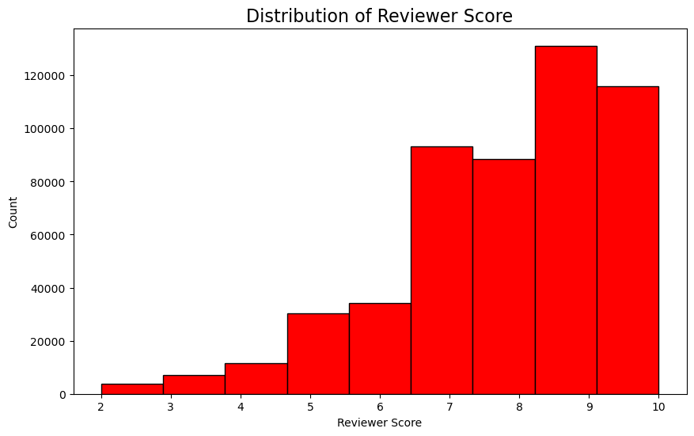

```python
 #plotting the distribution of the Reviewer_Score column

plt.figure(figsize=(10, 6))
plt.hist(hotel_df_cleaned['Reviewer_Score'], bins=9, color='red', edgecolor='black')
plt.title('Distribution of Reviewer Score', fontsize=16)
plt.xlabel('Reviewer Score')
plt.ylabel('Count')
plt.show()
```

```python
# creating a function to find all the numeric columns, and also the non-numeric columns

def find_numeric_and_non_numeric_columns(df):
    numeric_columns = []
    non_numeric_columns = []
    for column in df.columns:
        if df[column].dtype == 'int64' or df[column].dtype == 'float64':
            numeric_columns.append(column)
        else:
            non_numeric_columns.append(column)

    print(f'The numeric columns are: {numeric_columns}')
    print(f'The non-numeric columns are: {non_numeric_columns}')

find_numeric_and_non_numeric_columns(hotel_df_cleaned)
```

```
The numeric columns are: ['Additional_Number_of_Scoring', 'Average_Score', 'Review_Total_Negative_Word_Counts', 'Total_Number_of_Reviews', 'Review_Total_Positive_Word_Counts', 'Total_Number_of_Reviews_Reviewer_Has_Given', 'lat', 'lng']
The non-numeric columns are: ['Hotel_Address', 'Review_Date', 'Hotel_Name', 'Reviewer_Nationality', 'Negative_Review', 'Positive_Review', 'Reviewer_Score', 'Tags', 'days_since_review']
```

```python
# lets look at the non-numeric columns
for column in hotel_df_cleaned.columns:
    if hotel_df_cleaned[column].dtype == 'object':
        print(f'The unique values in the {column} column are: {hotel_df_cleaned[column].unique()}')
```

[output not shown]

[output cut: 254 more lines]

```
 '55 days' '56 days' '58 days' '67 days' '76 days' '108 day' '110 day'
 '112 day' '113 day' '117 day' '119 day' '123 day' '126 day' '131 day'
 '132 day' '141 day' '162 day' '183 day' '187 day' '201 day' '229 day'
 '250 day' '251 day' '257 day' '280 day' '315 day' '326 day' '329 day'
 '332 day' '339 day' '353 day' '358 day' '375 day' '378 day' '399 day'
 '404 day' '405 day' '437 day' '462 day' '556 day' '601 day' '626 day'
 '638 day' '657 day' '679 day' '690 day' '706 day' '710 day' '722 day'
 '724 day' '726 day' '4 days' '21 days' '38 days' '62 days' '103 day'
 '153 day' '159 day' '195 day' '259 day' '287 day' '320 day' '330 day'
 '368 day' '384 day' '455 day' '475 day' '575 day' '607 day' '666 day'
 '715 day' '729 day' '411 day' '421 day' '608 day' '629 day' '663 day'
 '689 day' '703 day' '477 day' '633 day' '5 days' '9 days' '13 days'
 '75 days' '77 days' '89 days' '122 day' '158 day' '300 day' '416 day'
 '61 days' '210 day' '316 day' '323 day' '83 days' '6 days' '11 days'
 '7 days' '96 days' '19 days']
```

# Data wrangling

We will the begin by converting the Reviewr_Score column into a binary column in the following way. Reviews that are below 9 should be encoded as 0('not good')and reviews with score 9 and 10 as 1 ('good')

```python
# binning the Reviewer_Score column into 2 categories: 0 for bad reviews (0-8) and 1 for good reviews (9-10)
hotel_df_cleaned['Reviewer_Score'] = hotel_df_cleaned['Reviewer_Score'].apply(lambda x: 0 if x <= 8 else 1)

# checking the results
hotel_df_cleaned['Reviewer_Score'].value_counts()
```

[output not shown]

# Hotel_Address column.

```python
# using the .value_counts() method to find the unique values in the Hotel_Address column
v_counts = hotel_df_cleaned['Hotel_Address'].value_counts()

# using the nunique() method to find the number of unique values in the Hotel_Address column
n_uniq = hotel_df_cleaned['Hotel_Address'].nunique()

print(v_counts)
print(f'There are {n_uniq} unique values in the Hotel_Address column.')
```

```
163 Marsh Wall Docklands Tower Hamlets London E14 9SJ United Kingdom              4789
372 Strand Westminster Borough London WC2R 0JJ United Kingdom                     4256
Westminster Bridge Road Lambeth London SE1 7UT United Kingdom                     4169
Scarsdale Place Kensington Kensington and Chelsea London W8 5SY United Kingdom    3578
7 Pepys Street City of London London EC3N 4AF United Kingdom                      3212
                                                                                  ...
21 rue Lavoisier 8th arr 75008 Paris France                                         12
2 4 Boundary Street Hackney London E2 7DD United Kingdom                            12
Via M Buonarroti 13 Fiera Milano City 20149 Milan Italy                             10
13 Rue Fran ois Ory 92120 Paris France                                              10
Johann Staud Stra e 32 16 Ottakring 1160 Vienna Austria                              8
Name: Hotel_Address, Length: 1493, dtype: int64
There are 1493 unique values in the Hotel_Address column.
```

with this many unique values, it will be difficult to turn this column into numeric values. Another problem is that the Hotel_Address column is not ordinal.So instead we can reduce the nuber of unique values by grouping the hotels by city and country.

```python
# extracting the city and country from the Hotel_Address column
hotel_df_cleaned['Hotel_City_Country'] = hotel_df_cleaned['Hotel_Address'].str.split(' ').str[-2:]

# checking the results
hotel_df_cleaned['Hotel_City_Country']
```

```
0         [Amsterdam, Netherlands]
1         [Amsterdam, Netherlands]
2         [Amsterdam, Netherlands]
3         [Amsterdam, Netherlands]
4         [Amsterdam, Netherlands]
                    ...
515733           [Vienna, Austria]
515734           [Vienna, Austria]
515735           [Vienna, Austria]
515736           [Vienna, Austria]
515737           [Vienna, Austria]
Name: Hotel_City_Country, Length: 515738, dtype: object
```

```python
# removing the square brackets from the Hotel_City_Country column
hotel_df_cleaned['Hotel_City_Country'] = hotel_df_cleaned['Hotel_City_Country'].str.join(' ').str.replace('[', '').str.replace(']', '')

# checking the results
hotel_df_cleaned['Hotel_City_Country'].value_counts()
```

```
United Kingdom           262301
Barcelona Spain           60149
Paris France              59928
Amsterdam Netherlands     57214
Vienna Austria            38939
Milan Italy               37207
Name: Hotel_City_Country, dtype: int64
```

```python
# replacing the duplicates with the correct values
hotel_df_cleaned['Hotel_City_Country'] = hotel_df_cleaned['Hotel_City_Country'].str.replace('Wien,', 'Vienna').str.replace('Paris,', 'Paris').str.replace('Barcelona,', 'Barcelona').str.replace('United Kingdom', 'London United Kingdom')

# checking the results
hotel_df_cleaned['Hotel_City_Country'].value_counts()
```

```
London United Kingdom    262301
Barcelona Spain           60149
Paris France              59928
Amsterdam Netherlands     57214
Vienna Austria            38939
Milan Italy               37207
Name: Hotel_City_Country, dtype: int64
```

```python
# dropping the Hotel_Address column
hotel_df_cleaned.drop('Hotel_Address', axis=1, inplace=True)

# checking the results
hotel_df_cleaned.columns
```

```
Index(['Additional_Number_of_Scoring', 'Review_Date', 'Average_Score',
       'Hotel_Name', 'Reviewer_Nationality', 'Negative_Review',
       'Review_Total_Negative_Word_Counts', 'Total_Number_of_Reviews',
       'Positive_Review', 'Review_Total_Positive_Word_Counts',
       'Total_Number_of_Reviews_Reviewer_Has_Given', 'Reviewer_Score', 'Tags',
       'days_since_review', 'lat', 'lng', 'Hotel_City_Country'],
      dtype='object')
```

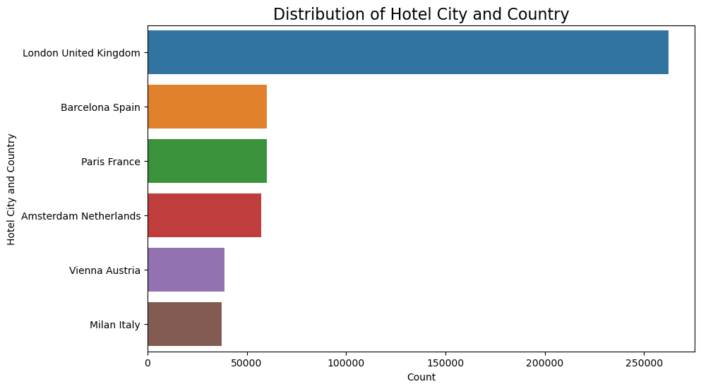

```python
# plotting the distribution of the Hotel_City_Country column
plt.figure(figsize=(10, 6))
sns.countplot(y=hotel_df_cleaned['Hotel_City_Country'], order=hotel_df_cleaned['Hotel_City_Country'].value_counts().index)
plt.title('Distribution of Hotel City and Country', fontsize=16)
plt.xlabel('Count')
plt.ylabel('Hotel City and Country')
plt.show()
```

```python
# using get_dummies to convert the Hotel_City_Country column to dummy variables
hotel_df = pd.get_dummies(hotel_df_cleaned, columns=['Hotel_City_Country'], drop_first=True)

# checking the results
print(hotel_df.columns)

# inspecting the first 3 rows of the dataset
hotel_df.sample(3)
```

```
Index(['Additional_Number_of_Scoring', 'Review_Date', 'Average_Score',
       'Hotel_Name', 'Reviewer_Nationality', 'Negative_Review',
       'Review_Total_Negative_Word_Counts', 'Total_Number_of_Reviews',
       'Positive_Review', 'Review_Total_Positive_Word_Counts',
       'Total_Number_of_Reviews_Reviewer_Has_Given', 'Reviewer_Score', 'Tags',
       'days_since_review', 'lat', 'lng', 'Hotel_City_Country_Barcelona Spain',
       'Hotel_City_Country_London United Kingdom',
       'Hotel_City_Country_Milan Italy', 'Hotel_City_Country_Paris France',
       'Hotel_City_Country_Vienna Austria'],
      dtype='object')
```

|  | Additional_Number_of_Scoring | Review_Date | Average_Score | Hotel_Name | Reviewer_Nationality | Negative_Review | Review_Total_Negative_Word_Counts | Total_Number_of_Reviews | Positive_Review | Review_Total_Positive_Word_Counts | ... | Reviewer_Score | Tags | days_since_review | lat | lng | Hotel_City_Country_Barcelona Spain | Hotel_City_Country_London United Kingdom | Hotel_City_Country_Milan Italy | Hotel_City_Country_Paris France | Hotel_City_Country_Vienna Austria |
| --- | --- | --- | --- | --- | --- | --- | --- | --- | --- | --- | --- | --- | --- | --- | --- | --- | --- | --- | --- | --- | --- |
| 308937 | 451 | 12/16/2015 | 8.5 | Swiss tel Amsterdam | Turkey | No Negative | 0 | 2756 | Superb very classy and stylish hotel the staf... | 33 | ... | 1 | [' Business trip ', ' Solo traveler ', ' Class... | 596 day | 52.373527 | 4.893304 | 0 | 0 | 0 | 0 | 0 |
| 71083 | 230 | 5/24/2017 | 8.6 | H tel Bedford | United Kingdom | Nothing | 3 | 1703 | Lovely large room with small balcony Definite... | 15 | ... | 1 | [' Leisure trip ', ' Group ', ' Superior Room ... | 71 days | 48.872059 | 2.323680 | 0 | 0 | 0 | 1 | 0 |
| 371967 | 53 | 7/26/2016 | 8.6 | Ofelias Hotel 4 Sup | France | Nothing it was really great | 6 | 343 | We were really delighted with hotel Clean lux... | 31 | ... | 1 | [' Leisure trip ', ' Family with young childre... | 373 day | 41.395758 | 2.182240 | 1 | 0 | 0 | 0 | 0 |

3 rows × 21 columns

# Review _Date

```python
# using the .value_counts() method to find the unique values in the Review_Date column
v_counts = hotel_df['Review_Date'].value_counts()

# using the nunique() method to find the number of unique values in the Review_Date column
n_uniq = hotel_df['Review_Date'].nunique()

print(v_counts)
print(f'There are {n_uniq} unique values in the Review_Date column.')
```

```
8/2/2017      2585
9/15/2016     2308
4/5/2017      2284
8/30/2016     1963
2/16/2016     1940
              ...
9/10/2016      199
11/27/2015     194
4/3/2017       192
4/1/2017       173
4/2/2017       143
Name: Review_Date, Length: 731, dtype: int64
There are 731 unique values in the Review_Date column.
```

```python
# converting the Review_Date column to datetime
hotel_df['Review_Date'] = pd.to_datetime(hotel_df['Review_Date'])

# checking the results
hotel_df['Review_Date']
```

```
0        2017-08-03
1        2017-08-03
2        2017-07-31
3        2017-07-31
4        2017-07-24
            ...
515733   2015-08-30
515734   2015-08-22
515735   2015-08-19
515736   2015-08-17
515737   2015-08-09
Name: Review_Date, Length: 515738, dtype: datetime64[ns]
```

```python
# extracting the year from the Review_Date column
hotel_df['Review_Year'] = hotel_df['Review_Date'].dt.year

# extracting the month from the Review_Date column
hotel_df['Review_Month'] = hotel_df['Review_Date'].dt.month

# extracting the day from the Review_Date column
hotel_df['Review_Day'] = hotel_df['Review_Date'].dt.day

# checking the results
hotel_df.sample(3)
```

|  | Additional_Number_of_Scoring | Review_Date | Average_Score | Hotel_Name | Reviewer_Nationality | Negative_Review | Review_Total_Negative_Word_Counts | Total_Number_of_Reviews | Positive_Review | Review_Total_Positive_Word_Counts | ... | lat | lng | Hotel_City_Country_Barcelona Spain | Hotel_City_Country_London United Kingdom | Hotel_City_Country_Milan Italy | Hotel_City_Country_Paris France | Hotel_City_Country_Vienna Austria | Review_Year | Review_Month | Review_Day |
| --- | --- | --- | --- | --- | --- | --- | --- | --- | --- | --- | --- | --- | --- | --- | --- | --- | --- | --- | --- | --- | --- |
| 515480 | 168 | 2016-12-23 | 8.1 | Atlantis Hotel Vienna | Austria | No Negative | 0 | 2823 | location was excellent right around the corne... | 28 | ... | 48.203745 | 16.335677 | 0 | 0 | 0 | 0 | 1 | 2016 | 12 | 23 |
| 8482 | 1274 | 2017-04-20 | 7.7 | Grand Royale London Hyde Park | Belgium | Nothing really to complain about Breakfast is... | 23 | 6539 | It is relatively nice hotel rather typical in... | 31 | ... | 51.510995 | -0.186342 | 0 | 1 | 0 | 0 | 0 | 2017 | 4 | 20 |
| 299793 | 326 | 2016-01-29 | 8.6 | The Chelsea Harbour Hotel | United Kingdom | Waiter refused to remove dirty plate said it ... | 14 | 1032 | Rooms were excellent | 5 | ... | 51.475656 | -0.181389 | 0 | 1 | 0 | 0 | 0 | 2016 | 1 | 29 |

3 rows × 24 columns

# Hotel_Name

```python
# using the .value_counts() method to find the unique values in the Hotel_Name column
v_counts = hotel_df['Hotel_Name'].value_counts()

# using the nunique() method to find the number of unique values in the Hotel_Name column
n_uniq = hotel_df['Hotel_Name'].nunique()

print(v_counts)
print(f'There are {n_uniq} unique values in the Hotel_Name column.')
```

```
Britannia International Hotel Canary Wharf           4789
Strand Palace Hotel                                  4256
Park Plaza Westminster Bridge London                 4169
Copthorne Tara Hotel London Kensington               3578
DoubleTree by Hilton Hotel London Tower of London    3212
                                                     ...
Ibis Styles Milano Palmanova                           12
Hotel Eitlj rg                                         12
Hotel Wagner                                           10
Mercure Paris Porte d Orleans                          10
Hotel Gallitzinberg                                     8
Name: Hotel_Name, Length: 1492, dtype: int64
There are 1492 unique values in the Hotel_Name column.
```

```python
# finding the percentage of the column
percentage = v_counts/hotel_df.shape[0]*100

print(percentage)
```

```
Britannia International Hotel Canary Wharf           0.928572
Strand Palace Hotel                                  0.825225
Park Plaza Westminster Bridge London                 0.808356
Copthorne Tara Hotel London Kensington               0.693763
DoubleTree by Hilton Hotel London Tower of London    0.622797
                                                       ...
Ibis Styles Milano Palmanova                         0.002327
Hotel Eitlj rg                                       0.002327
Hotel Wagner                                         0.001939
Mercure Paris Porte d Orleans                        0.001939
Hotel Gallitzinberg                                  0.001551
Name: Hotel_Name, Length: 1492, dtype: float64
```

[figure not shown]

```python
# plotting the distribution of the Hotel_Name column
plt.figure(figsize=(10, 6))

percentage.plot(kind='bar')

plt.title('Distribution of Hotel Name', fontsize=16)
plt.xlabel('Hotel Name')
plt.ylabel('Count')
plt.show()
```

```python
# grouping the hotels by the number of reviews
low = hotel_df['Hotel_Name'].map(percentage) < 0.1
medium = hotel_df['Hotel_Name'].map(percentage).between(0.1, 0.38)
high = hotel_df['Hotel_Name'].map(percentage) > 0.38

# using the mask() method to replace the low frequency categories with 'Low Popularity'
hotel_df['Hotel_Name'] = hotel_df['Hotel_Name'].mask(low, 'Low Popularity')

# using the mask() method to replace the medium frequency categories with 'Medium Popularity'
hotel_df['Hotel_Name'] = hotel_df['Hotel_Name'].mask(medium, 'Medium Popularity')

# using the mask() method to replace the high frequency categories with 'High Popularity'
hotel_df['Hotel_Name'] = hotel_df['Hotel_Name'].mask(high, 'High Popularity')

# checking the results
hotel_df['Hotel_Name'].value_counts()
```

```
Medium Popularity    246010
Low Popularity       216740
High Popularity       52988
Name: Hotel_Name, dtype: int64
```

# Conclusion